# Eduardo Demetrio

Controle estatistisco de qualidade

2025-04-27

# Repositório.

- Teremos também um repositório com todas listas no GitHub. [🔗 Repositório no GitHub](https://github.com/EduardoDemetrio/Faculdade/tree/lista/5_Periodo/Controle_estatistico_qualidade)

# Como será feito

- Irei construir um documento com as perguntas e respostas, também enviarei um arquivo em código R que será usado para testes e cálculos mais elaborados.

## Questão 1

Os diâmetros de oito mancais selecionados ao acaso são os seguintes (em mm): 50,001, 50,002, 49,998, 50,006, 50,005, 49,996, 50,003, 50,004.  
a. Calcule a média amostral  
b. Calcule o desvio-padrão amostral

**Questão 1-A:** 50.00187  
**Questão 1-B:** 0.003440826

## Questão 2

O tempo de vida até falhar em horas de um componente eletrônico sujeito a um teste de durabilidade acelerado é mostrado abaixo para uma amostra com tamanho n = 40. Para acelerar a falha no teste, as unidades experimentais são testadas sob uma temperatura elevada.  
a. Calcule a média amostral e o desvio-padrão.  
b. Construa o histograma.  
c. Ache a mediana e os quartis

**Questão 2-A**: média: 130 e desvio: 9.92  
**Questão 2-B**: Histograma abaixo

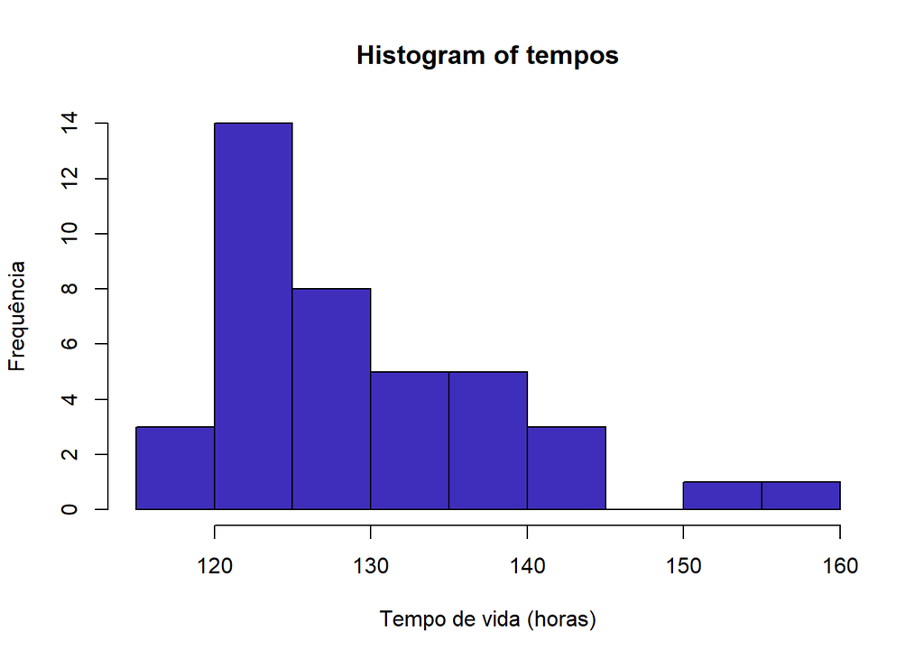

**Questão 2-C**: Mediana: 128  
Quartil 25%: 124  
Quartil 75%: 133.75

## Questão 3

Os dados abaixo são leituras do rendimento de um processo químico em dias sucessivos (leia da esquerda para a direita). Faça o histograma dos dados, comente o aspecto do histograma e verifique se o histograma lembra alguma distribuição de probabilidade conhecida.

Com base no histograma conseguimos levemente ver uma normal, pórem ainda com algumas distorções, como podemos ver nesse gráfico.

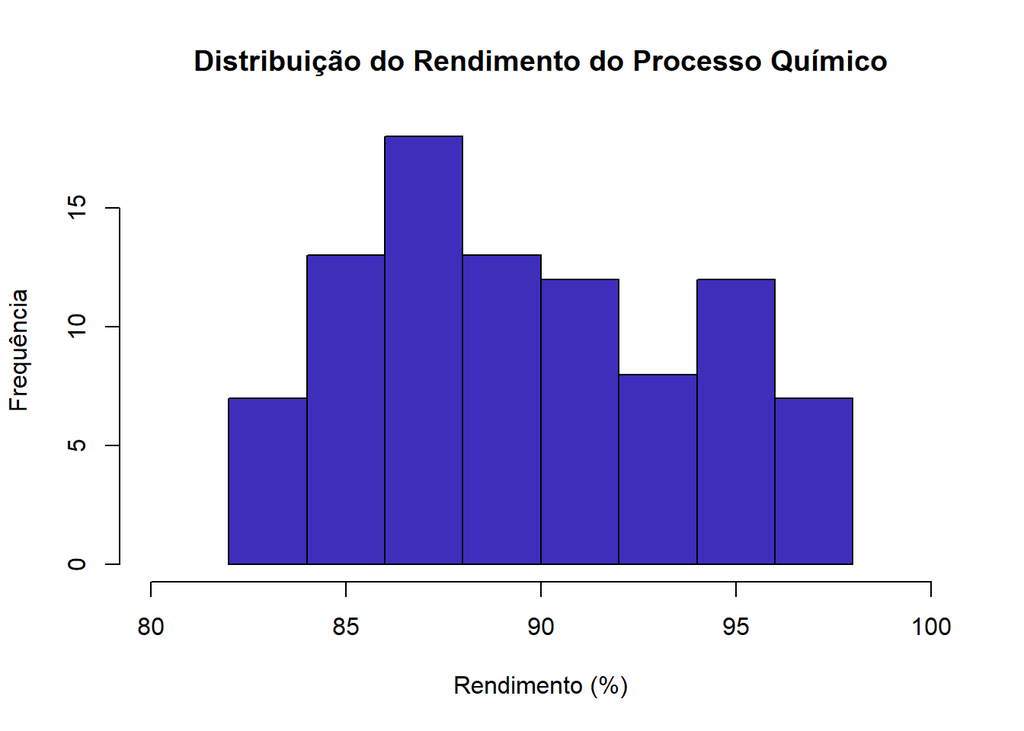

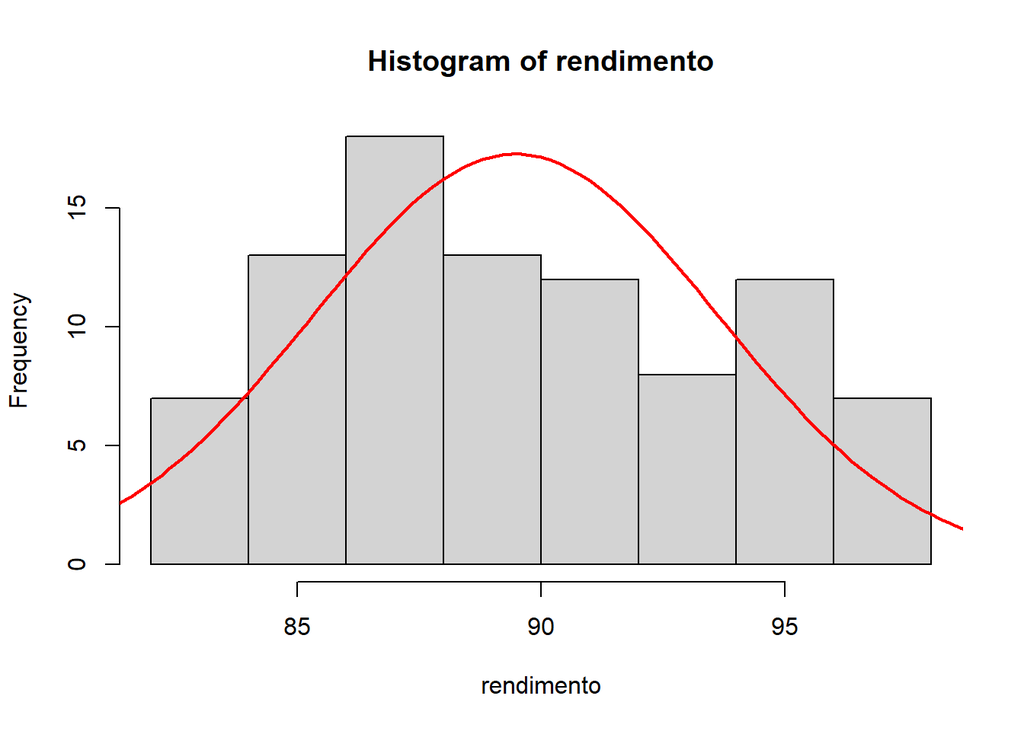

## Questão 4

Considere o rendimento do processo químico do exercício anterior. Calcule a média amostral e o desvio padrão.

Média amostral: 89.47556  
desvio: 4.157768

## Questão 5

Suponha que dois dados não viciados são lançados e uma variável aleatória observada, digamos X, que corresponde a soma das duas faces superiores. Descreva o espaço amostral do experimento e determine a função de probabilidade da v.a. X

**Espaço amostral:** Dado1xDado2 = {(1,1),(1,2),(1,3),(1,4),(1,5),(1,6),(2,1)….(6,6)}, resultando em 36 resultados possiveis.  
**Função de probabilidade:** (discreta, P(X=x))  
n° de combinação  
36 (total de resultados possiveis)  
consiste na ideia de probabilidade clássica.

## Questão 7

**Questão 7-B** : 0.017 **Questão 7-C** : 0.016

## Questão 8

A distribuição de probabilidade da v.a. contínua X tem a seguinte função densidade de probabilidade f(x) ke^kx. Ache a valor da constante k e também a média e a variância de X.

Vamos usar a regra da função densidade aonde igualamos a função a 1, calculando a integral, a função assim já está normalizada para qualquer k>0.  
Sua média seria 1/k e variância 1/k^2

## Questão 9

A v.a. X assume os valores 1, 2, ou 3 com probabilidades (1+3k)/3, (1+2k)/3 e (0,5+5k)/3, respectivamente. a. Determine o valor adequado de k.  
b. Determine a média e a variância de X.  
c. Determine a função distribuição acumulada de X.

**Questão 9-A** Valores de K são [0.3833; 0.3667; 0.25]  
**Questão 9-B** A média: 1.8667 e variância: 0.6156  
**Questão 9-C** Sua DA: [0.3833; 0.75; 1]

## Questão 10

A distribuição de probabilidade de uma v.a. discreta é: p(x)=kr^x 0<r<1 Ache o valor adequado de k sabendo-se que o contradomínio de x é 0, 1, 2, …..

O valor adequado de K é k=1-r

## Questão 11

Uma fábrica de calculadoras eletrônicas oferece garantia de um ano. Se a calculadora falha por qualquer razão neste período, ela é substituída. O tempo de falha é modelado pela seguinte distribuição de probabilidade f(x) 0,125e^-0,125x . x>0 a. Qual a porcentagem de calculadoras que falham no período da garantia? b. O custo de fabricação da calculadora é $50 e o lucro é de $25. Qual é o efeito da garantia de substituição sobre o lucro?

**Questao 11-A** Sua porcentagem de falha na gatantia consistem em 11,75%  
**Questao 11-B** Seu lucro esperado por unidade está em $19.12

## Questão 12

A variabilidade do volume engarrafado de uma bebida está sendo analisada. Uma amostra com tamanho n = 10 foi tomada do processo. Os volumes medidos e os resultados são os seguintes, na unidade adequada:  
10,05 10,03 10,02 10,04 10,05 10,01 10,02 10,02 10,03 10,01  
Descreva a amostra.

Média: 10.028  
Mediana: 10.025  
Desvio-padrão: 0.0148  
Variância: 2e-04

Consistência: Processo preciso (baixa variabilidade).  
Viés: Leve tendência a encher acima do alvo (média 10.028).  
Ação recomendada: Ajustar a calibração da máquina para reduzir o viés, mantendo a precisão.

## Questão 13

Seja a v.a. X que representa o número de itens defeituosos presentes em uma amostra de tamanho n=10, tomada de um lote que possui 100 itens, inclusive 5 defeituosos. A amostra é tomada sem reposição. Calcule a probabilidade de aparecer na amostra no máximo 1 dos defeituosos.

Probabilidade de 0 defeituosos: 0.5838. Aproximadamente 58.38% de chance de não haver defeituosos na amostra.  
Probabilidade de 1 defeituoso: 0.3394. Aproximadamente 33.94% de chance de haver exatamente 1 defeituoso.  
Probabilidade total (no máximo 1 defeituoso): 0.9231. 92.31% de chance de a amostra ter no máximo 1 item defeituoso.

## Questão 14

Em um processo de produção de tecido aparecem determinado defeito com uma média de 4 defeitos por unidade de comprimento. Calcule probabilidade de em uma unidade de comprimento selecionada ao caso ocorrer no máximo 2 defeitos.

P(X=0): 0.0183  
P(X=1): 0.0733  
P(X=2): 0.1465  
P(X ≤ 2): 0.2381

## Questão 15

A resistência a tração é uma característica muito importante do papel usada para fazer sacolas paracarregar mantimentos. Supondo que a v.a. X represente esta força e que ela tem uma distribuição N(µ=40,σ2=4) para determinado tipo de papel e que a alça dessa sacola requer que a força de resistência seja de pelo menos 35 unidades, calcule a probabilidade de que uma sacola produzida com este papel atinja ou exceda a especificação.

Probabilidade (X ≥ 35): 0.9938 ou 99.38%  
Alta probabilidade (99.38%) de atender à especificação mínima de 35 unidades.

## Questão 16

O diâmetro do pino de metal usado em uma unidade de “disk-drive” é normalmente distribuída com média de 0,2508 e desvio-padrão de 0,0005 unidades. A especificação de projeto do pino estabeleceu que o diâmetro deve ficar entre 0,2500 +/- 0,0015 unidades. Determine a fração de defeituosos produzidos de acordo com a especificação.

Defeitos por baixo: 0 %  
Defeitos por alta: 8.08 %  
Total de defeituosos: 8.08 %

## Questão 17

Muitos experimentos são tais que os resultados possíveis apresentam ou não uma determinada característica. Uma moeda é lançada: o resultado é “cara”, ou não é; um dado é lançado: ou ocorre face 5, ou não (ocorrendo, então, uma das faces 1, 2, 3, 4 ou 6); uma pessoa é escolhida, ao acaso, entre os moradores de uma cidade e pergunta-se se ela diz “sim” ou “não” a um projeto da prefeitura. Estes experimentos resultam numa variável aleatória de Bernoulli e também são chamados “ensaios Bernoulli”. A função de probabilidade discreta que uma variável aleatória, digamos, X assume é dada pela função de probabilidade:  
a. Encontre a E(X)  
b. Encontre a Var(X)  
c. Encontre a função geratriz de momentos, Mx(t), da variável aleatória X  
d. Através da função geratriz de momentos, encontre a média e a variância da variável aleatória X.

Teórico - E(X): 0.3 Var(X): 0.21  
Amostral - E(X): 0.300 Var(X): 0.210

## Questão 18

Um lote é constituído de M peças das quais D(D<=M) defeituosas. Uma amostra aleatória de n peças é selecionada deste lote sem reposição, e o número de peças desta amostra com defeitos, digamos x é observada. Então x é uma variável aleatória com distribuição de probabilidade Hipergeométrica conforme a. Encontre E(X) b. Encontre Var(X).

E(X): 2  
Var(X): 1.4545

## Questão 24

A Urna I contém 2 (duas) bolas brancas e 3 (três) pretas; a Urna II contém 4 (quatro) bolas brancas e 1 (uma) preta; a Urna III contém 3 (três) bolas brancas e 4 (quatro) pretas. Escolhe-se uma Urna ao acaso e dela extrai-se uma bola, que tem cor branca. Qual a probabilidade de ter sido escolhida a Urna I.

Probabilidade de ser a Urna I dado B: 0.2456 ou 24.56%

## Questão 27

Se X1,X2, …, Xn são variáveis aleatórias independentes, cada Xi com a mesma média µ e mesma variância o2.  
Calcule a E(x) e a Var(x), onde X = 1/n Somatorio xi

E(X̄) simulado: 50.00  
Var(X̄) simulada: 2.51

## Questão 28

Joga-se uma moeda três vezes. Se X é uma variável aleatória que representa o número de caras a. construa uma tabela da distribuição de probabilidade de X. b. faça o gráfico da distribuição de probabilidade de X, c. determine a função distribuição (acumulada) de X, d. faça o gráfico da função distribuição (acumulada) de X, e. determine a média e a variância de X.

```
##   X Probabilidade
## 1 0         0.125
## 2 1         0.375
## 3 2         0.375
## 4 3         0.125
```

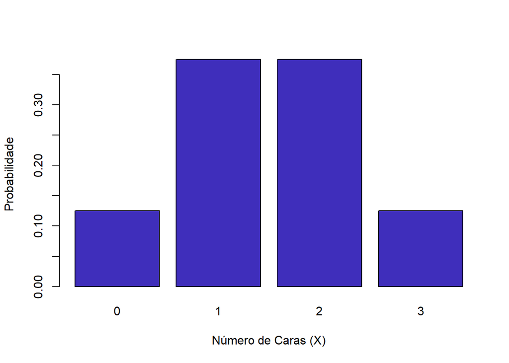

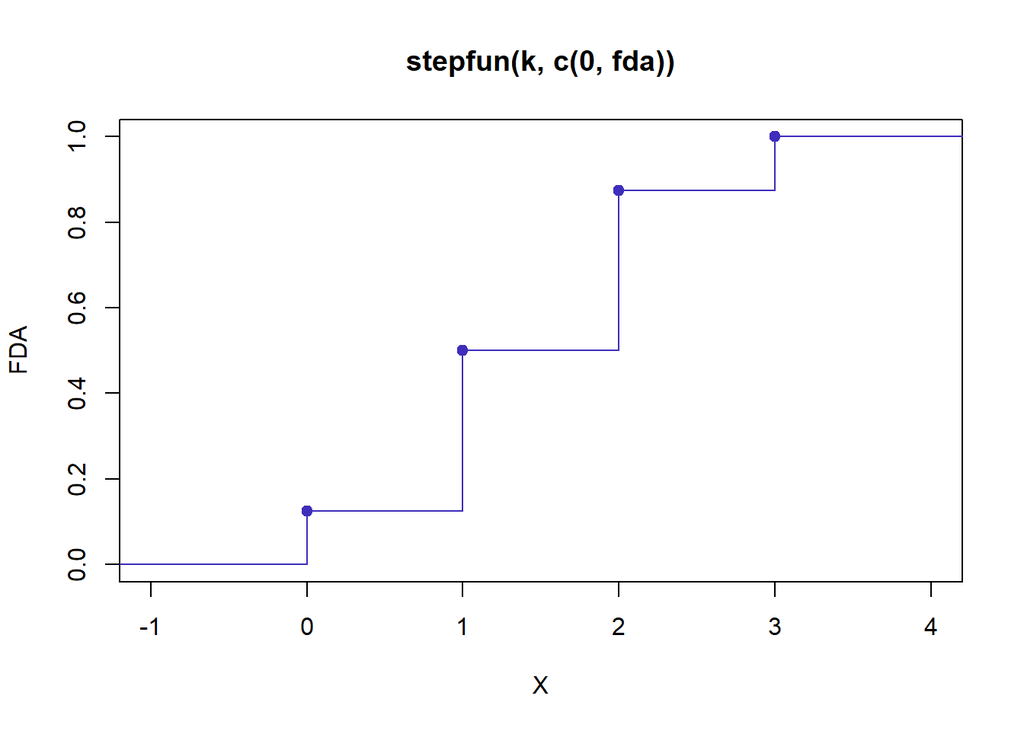

```
## Média: 1.5
## Variância: 0.75
```

## Questão 29

Uma urna contém 5 bolas brancas e 3 pretas. Extraem-se duas bolas aleatoriamente, sem reposição. Seja X o número de bolas brancas. a. determine a distribuição de probabilidade de X b. faça o gráfico da distribuição de probabilidade de X c. determine a função distribuição (acumulada) de X, d. faça o gráfico da função distribuição (acumulada) de X, e. determine a média e a variância de X.

```
##   X Probabilidade
## 1 0        0.1071
## 2 1        0.5357
## 3 2        0.3571
```

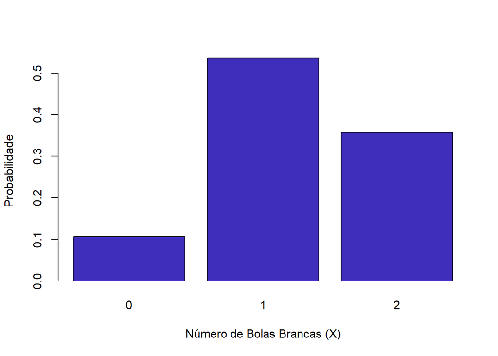

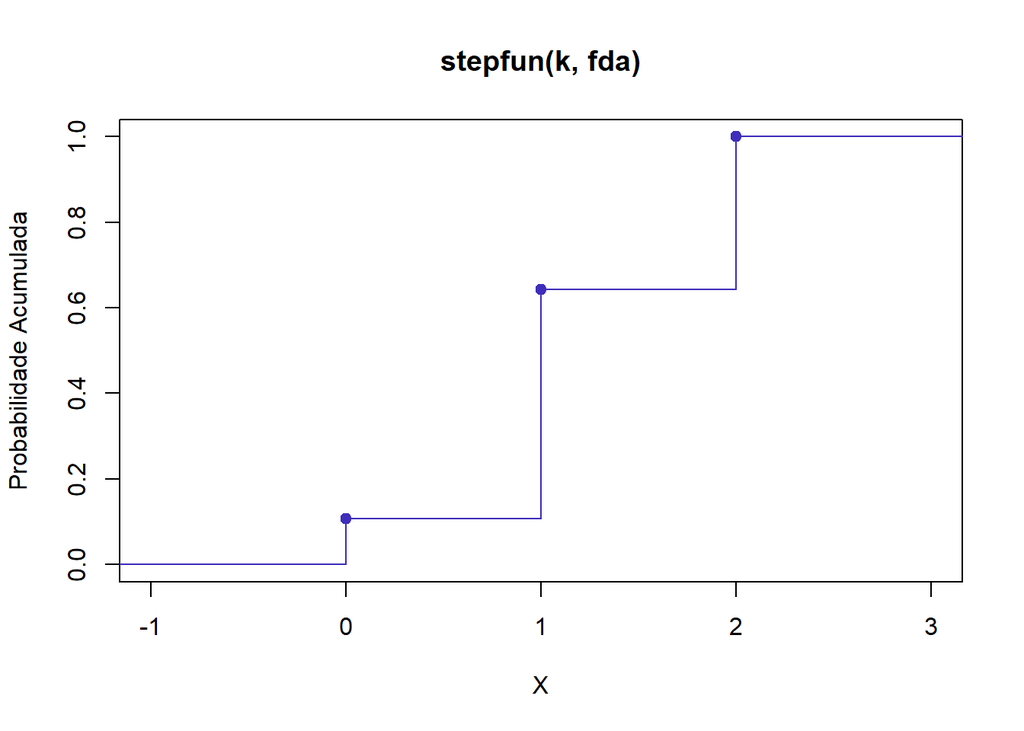

```
## Média: 1.25
## Variância: 0.4018
```

## Questão 30

Uma urna contém 5 bolas brancas e 3 pretas. Extraem-se duas bolas aleatoriamente, com reposição. Seja X o número de bolas brancas. a. determine a distribuição de probabilidade de X b. faça o gráfico da distribuição de probabilidade de X c. determine a função distribuição (acumulada) de X, d. faça o gráfico da função distribuição (acumulada) de X, e. determine a média e a variância de X.

```
##   X Probabilidade
## 1 0        0.1406
## 2 1        0.4688
## 3 2        0.3906
```

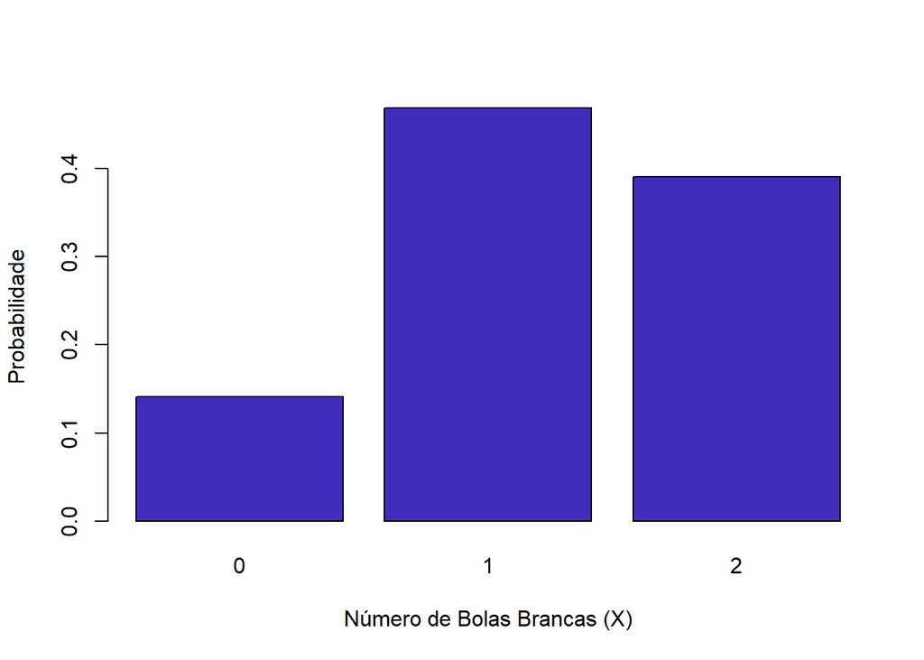

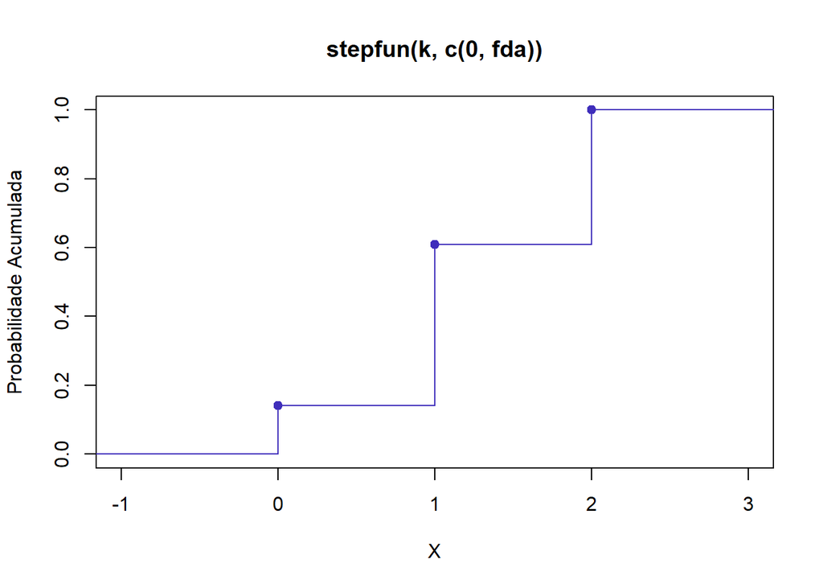

```
## Média: 1.25
## Variância: 0.4688
```

## Questão 31

Seja Z uma variável aleatória que represente o número de caras menos o número de coroas em duas jogadas de uma moeda “honesta”. a. determine a distribuição de probabilidade de X b. faça o gráfico da distribuição de probabilidade de X c. determine a função distribuição (acumulada) de X, d. faça o gráfico da função distribuição (acumulada) de X, e. determine a média e a variância de X.

```
##    Z Probabilidade
## 1 -2          0.25
## 2  0          0.50
## 3  2          0.25
```

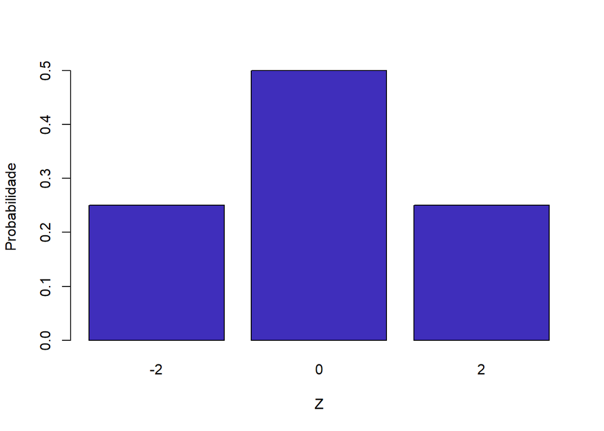

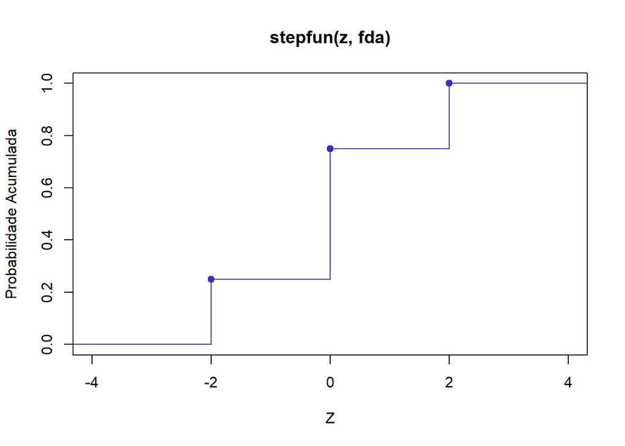

```
## Média: 0
## Variância: 2
```

## Questão 32

Seja X uma variável aleatória que represente o número de ases em uma extração aleatória de 4 cartas de um baralho usual de 52 cartas. a. determine a distribuição de probabilidade de X b. faça o gráfico da distribuição de probabilidade de X c. determine a função distribuição (acumulada) de X, d. faça o gráfico da função distribuição (acumulada) de X, e. determine a média e a variância de X.

```
##   X Probabilidade
## 1 0        0.7187
## 2 1        0.2556
## 3 2        0.0250
## 4 3        0.0007
## 5 4        0.0000
```

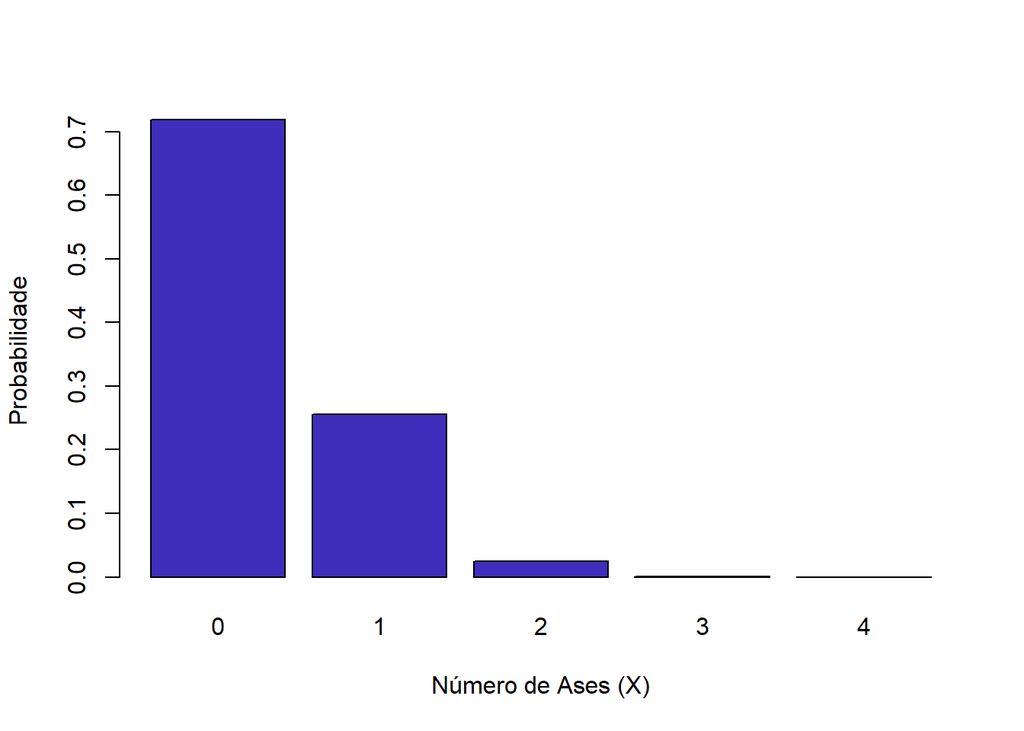

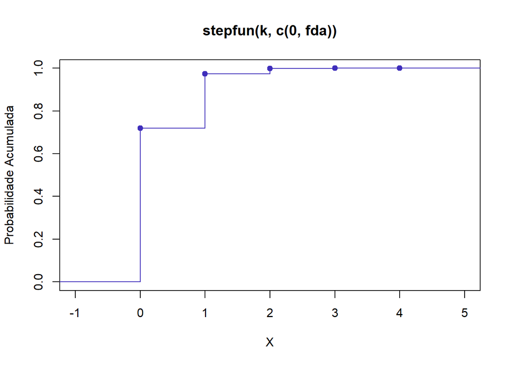

```
## Média: 0.3077
## Variância: 0.2673
```

## Questão 33

A função densidade de probabilidade da variável aleatória contínua X é a. determine a constante c de modo que a função acima seja uma densidade, b. calcule P(1 <= X <= 2) c. determine a função distribuição (acumulada) da variável aleatória, d. encontre a média da variável aleatória X e. encontre a variância da variável aleatória X.

c <- 1/9  
P(1 ≤ X ≤ 2): 0.2592593 (≈ 0.2593)  
F(1.5): 0.125  
Média: 2.25  
Variância: 0.3375 (≈ 0.3375)

## Questão 34

Seja X uma variável aleatória com densidade: a. Determine o valor da constante c b. Ache o valor lambda tal que Fx(lambda) = 0,25. (lambda é o primeiro quartil da distribuição de X)

Primeiro quartil (α): -0.7937  
F(α) deve ser 0.25: 0.25

## Questão 35

Suponha que a variável aleatória X tenha a seguinte densidade “triangular”:  
a. Calcule E(X)  
b. Var(X)

E(X): 0  
Var(X): 0.1666667 (≈ 0.1667)

## Questão 36

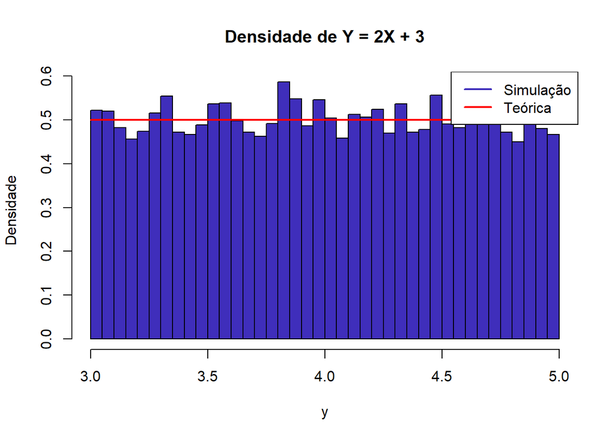